# Data Processing and Analysis

Kianté A. Fernandez

3/23/2020

Given what we have seen with the distributions to this point in addation to taking a look at the observation counts, I think we have a fair rationale for skewing the sampling.

Here is a list of all pilot subjects observations for yes and no:

[output not shown]

To confrim, lets take a look at a single subject.

First take a look at the distribution of Harm and Gain for a single subject.

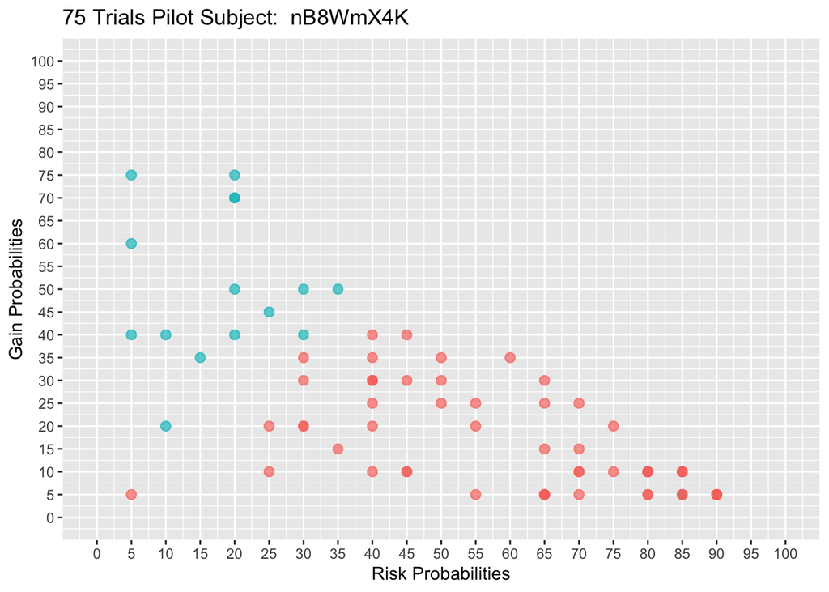

Okay, good enought we might say.

```
## [1] "nB8WmX4K"
```

```
##
## FALSE  TRUE
##    58    17
```

Yet the subject does not have quite a large amount of yes observations.Lets take a look at some density plots.

Here the y axis of the density plots are the probability of getting an x value between a range of x values at least that is the commonly how I have seen it defined. These are estimated using a Gaussian kernel via kernal density estimation.

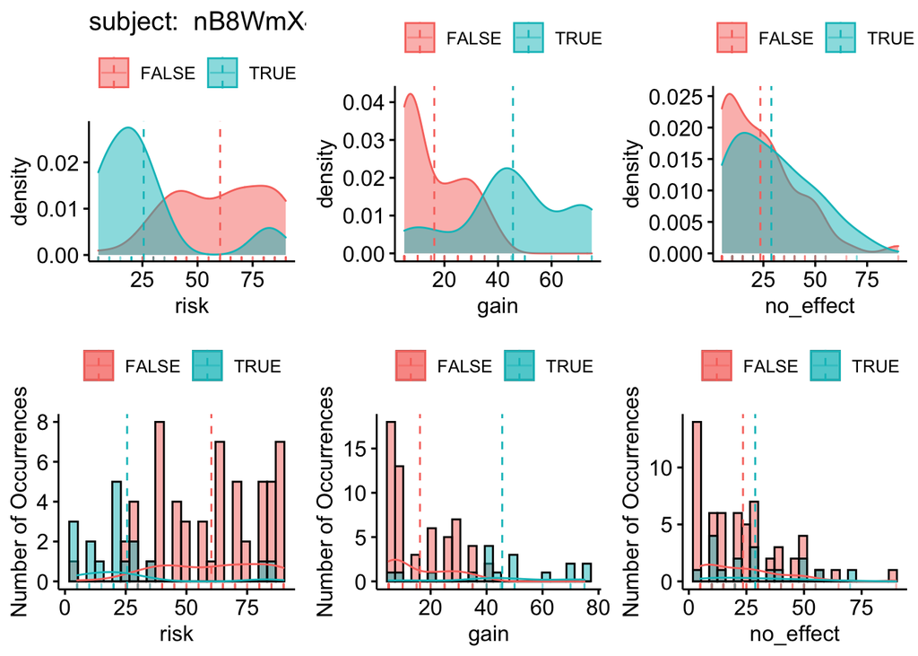

## A final thoughts

- Notice how sparce our gain distribution is.
- Also notice how we have are pulling our risk distribution from the oversample of 40 to 50 percent

I will upload the plots for all the pliot subjects in the dropbox.

Thanks for letting me get some practice in markdown.